# Final Project

#### loading Data

```r
library(ggplot2)
#settings used in the sumilation
  #sart dom: 0%
  #dom live: 50%
  #rec live: 75%
  #mutation:  3%
PopPath = 'Populations/'
Pop <- read.csv(PopPath %.% 'Population25.csv')[-4] #removing predator column since it is not used
attach(Pop)
  Pop$Tot = Rec+Dom+Het

  GeneA <- 2*Dom+Het
  GeneB <- 2*Rec+Het

detach(Pop)
dtable(Pop)
```

|  | Dom | Het | Rec | Tot |
| --- | --- | --- | --- | --- |
| 1 | 47 | 3 | 0 | 50 |
| 2 | 41 | 2 | 0 | 43 |
| 3 | 44 | 2 | 0 | 46 |
| 4 | 47 | 2 | 0 | 49 |
| 5 | 43 | 4 | 0 | 47 |
| 6 | 42 | 9 | 0 | 51 |
| 7 | 39 | 13 | 0 | 52 |
| 8 | 27 | 17 | 2 | 46 |
| 9 | 36 | 20 | 4 | 60 |
| 10 | 28 | 24 | 7 | 59 |

[output cut: 22 more lines]

#### barplot

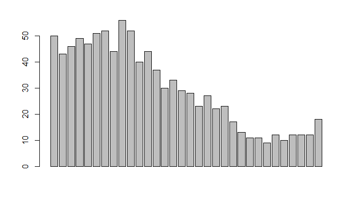

```r
attach(Pop,warn.conflicts = FALSE)
  M = nrow(Pop)
  N = 1:M

  barplot(Tot[N]-Rec[N]) #total not Rec
```

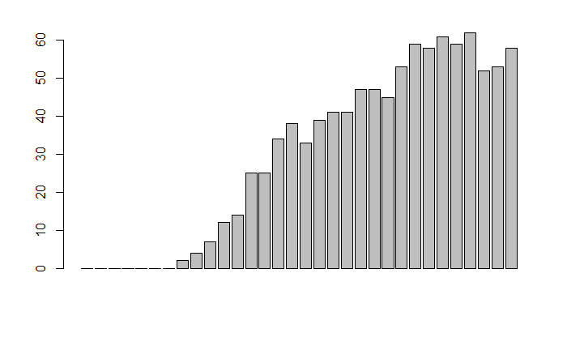

```r
  barplot(Rec[N]) #total Rec
```

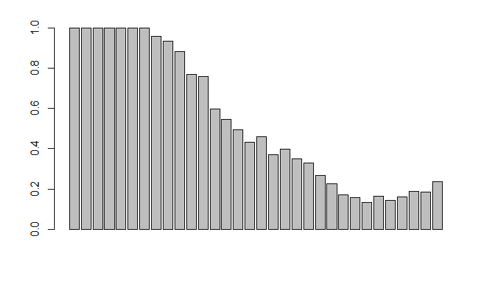

```r
  barplot((Tot[N]-Rec[N])/Tot[N]) #percent not Rec
```

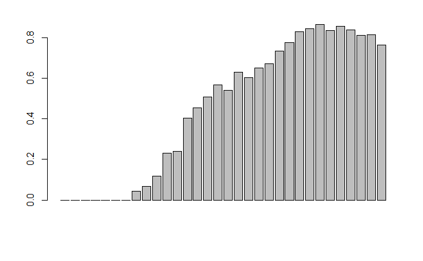

```r
  barplot(Rec[N]/Tot[N]) #Percent rec
```

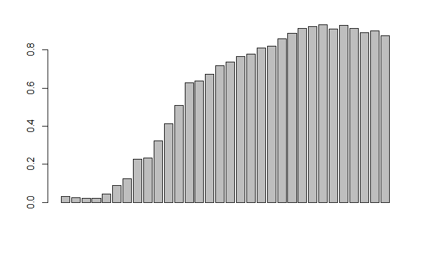

```r
  Pop$perc <- GeneB/(2*Tot) #percentage rec genes (gene B)
  barplot(Pop$perc)
```

```r
  #length(GeneB);length(Tot)
detach(Pop)
```

#### logistic regreassion

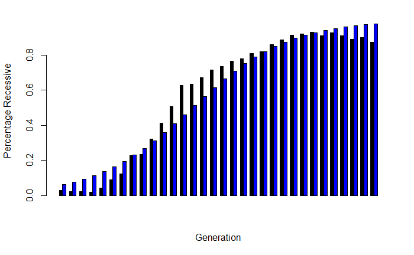

```r
library(stats4)
X <- N
#p.rec <- Pop$Rec/Pop$Tot # %recessive
Y = Pop$perc

results<-MLE(0,0)
barplot(rbind(Y,Logit.curve(N,results@coef)),beside = TRUE,xlab = 'Generation',ylab = 'Percentage Recessive', col = c('black','blue'))
```

```r
print.('Coefficients: ', results@coef)
```

```
Coefficients:  -2.895979 0.2105899
```

```r
print.('Minus Log Likelihood:', results@minuslogl(results@coef[1],results@coef[2]))
```

```
Minus Log Likelihood: 13.7204
```

#### $\chi^2$ test

```r
scale <- max(Pop$Tot) #scale by number of data points
X_2 <- chisq.stat(Y*scale,Logit.curve(N,results@coef)*scale); print.('$\\chi^2\\ =\\ '%+%X_2%+% '$.')
```

$\chi^2\ =\ 39.4929332409469$.

```r
pchisq(X_2,29,lower.tail = FALSE)
```

[1] 0.09257537

```r
print('When we scale by multiplying by the number of points, even though we would expect population growth to be logistic, in this case, seeing as the the P-value was only .1, it does not appear to be a good model. ')
```

[1] “When we scale by multiplying by the number of points, even though we would expect population growth to be logistic, in this case, seeing as the the P-value was only .1, it does not appear to be a good model.”

```r
scale2 <- max(Pop$Tot)/sum(Y) #scale by making the area under the curve equal to the total number of samples
X_2 <- chisq.stat(Y*scale2,Logit.curve(N,results@coef)*scale2); print.('$\\chi^2\\ =\\ '%+%X_2%+% '$.')
```

$\chi^2\ =\ 2.1282566918417$.

```r
pchisq(X_2,29,lower.tail = FALSE)
```

[1] 1

```r
print.('When we scale so that the total value is the number of points (which should be more accurate), we instead get a P-value of 1 suggesting that this is a VERY good model. This goes to show how sensitive $\\chi^2$ tests are since we only scales by a fact of $\\frac{1}{'%+%round(sum(Y),1)%+%'}$.')
```

When we scale so that the total value is the number of points (which should be more accurate), we instead get a P-value of 1 suggesting that this is a VERY good model. This goes to show how sensitive $\chi^2$ tests are since we only scales by a fact of $\frac{1}{18.6}$.

#### Modeling with Arctangent

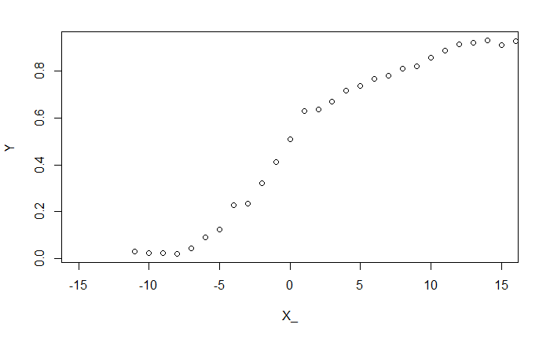

```r
#normalize
YY <- Y - ((min(Y)+max(Y))/2)
Y0 <- which.min(abs(YY)) #where the 0s of this YY is. not quite the correct 0, so the fit won't be perfect
X_ <- X - Y0

plot(X_,Y,xlim=c(-15,15))
```

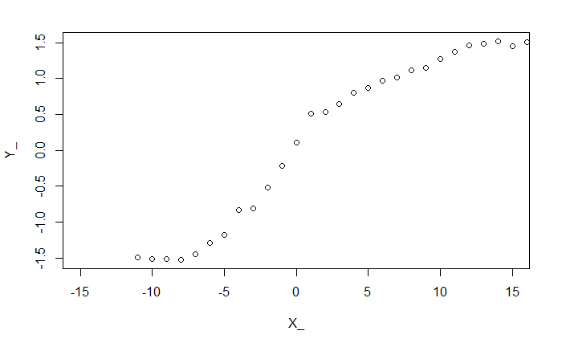

```r
Y.norm <- function(y) {
  y1 <- y - ((min(y)+max(y))/2)
  y_ <- y1 * atan(max(X_)) / max(y1)
  eval.parent(substitute(y.max <- max(y1)))
  return(y_)
}

Y.denorm <- function(y_) {
  y1 <- y_ / atan(max(X_)) * y.max
  y <- y1 + ((min(Y)+max(Y))/2)
  return(y)
}


Y_ <- Y.norm(Y)


plot(X_,Y_,xlim=c(-15,15))
```

```r
#take tanget
Y2 <- tan(Y_)

Coeff <- rev(P.m(X_,y=Y,reg=T,degree = 1));print.(c('a = ','b = ') %.% Coeff) #do linear regression by using projection matrix
```

a = 0.0347709377987493 b = 0.423420493637297

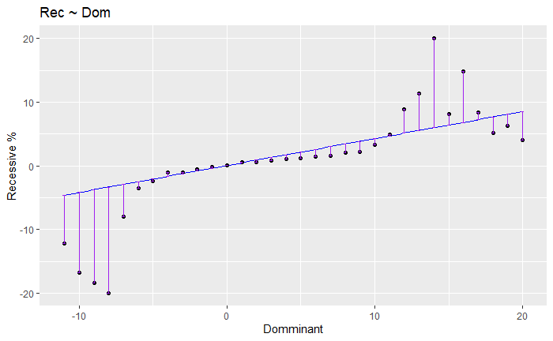

```r
fLine <- function(x) {
  Coeff[1]+Coeff[2]*x
}
# plot(X_,Y2,xlim=c(-15,15))
# curve(fLine(x),add = TRUE,col='blue')

expect  <- fLine(X_)
observe <- Y2

vals <- expect %+% observe
val.list <- as.list(as.data.frame(t(vals)))

data_frame <- data.frame(x=N-Y0,val=observe,mins=unlist(lapply(val.list, min)),maxs=unlist(lapply(val.list, max)))

ggplot(data_frame, aes(x)) +
  stat_function(fun=fLine,colour = 'blue') +
  geom_point( x=N-Y0, y=observe)+
  geom_errorbar(aes(ymin=mins, ymax=maxs), width=.2,
                 position=position_dodge(0.05), colour = 'purple') +
  labs(x = 'Domminant', y = 'Recessive %', title = 'Rec ~ Dom')
```

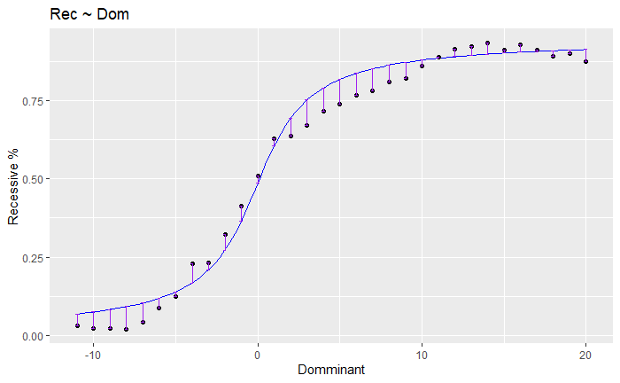

```r
#undo tanget


y.detan <- function(x) {
  Y.denorm(atan(fLine(x)))
}


# plot(X_,Y,xlim=c(-15,15))
# curve(Y.denorm(atan(fLine(x))),add = TRUE,col='blue')

expect  <- y.detan(X_)
observe <- Y

vals <- expect %+% observe
val.list <- as.list(as.data.frame(t(vals)))

data_frame <- data.frame(x=X_,val=observe,mins=unlist(lapply(val.list, min)),maxs=unlist(lapply(val.list, max)))

ggplot(data_frame, aes(x)) +
  stat_function(fun=y.detan,colour = 'blue') +
  geom_point( x=X_, y=observe)+
  geom_errorbar(aes(ymin=mins, ymax=maxs), width=.2,
                 position=position_dodge(0.05), colour = 'purple') +
  labs(x = 'Domminant', y = 'Recessive %', title = 'Rec ~ Dom')
```

```r
#multiply by number of data points for χ2 test
expect  %*=% scale
observe %*=% scale

X_2 <- chisq.stat(observe,expect); print.('$\\chi^2\\ =\\ '%+%X_2%+% '$.')
```

$\chi^2\ =\ 22.7712904230956$.

```r
pchisq(X_2,29,lower.tail = FALSE); print.('This value is pretty high. ~0.8. That shows that this is a pretty good fit (which can easily be seen). Overall it is quite interesting that an arctanget curve was the best fit.')
```

[1] 0.7869044 This value is pretty high. ~0.8. That shows that this is a pretty good fit (which can easily be seen). Overall it is quite interesting that an arctanget curve was the best fit.

```r
#set area under curve to number of data points
expect  %/=% sum(Y)
observe %/=% sum(Y)

X_2 <- chisq.stat(observe,expect); print.('$\\chi^2\\ =\\ '%+%X_2%+% '$.')
```

$\chi^2\ =\ 1.22713476178509$.

```r
pchisq(X_2,29,lower.tail = FALSE); print.('This gives a value of 1 which demonstrates a near perfect fit, but since we can see that the version which has larger values (and thus has larger absolute error) is better than the logistic fit, and so is still a better fit.')
```

[1] 1 This gives a value of 1 which demonstrates a near perfect fit, but since we can see that the version which has larger values (and thus has larger absolute error) is better than the logistic fit, and so is still a better fit.

#### population change matrix

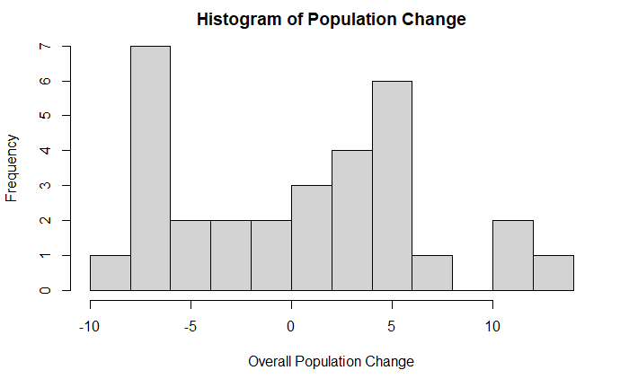

```r
PopChange <- matrix(nrow = M,ncol = ncol(Pop)); colnames(PopChange) <- colnames(Pop) %.% '.inc' #initialize population change matrix
for (i in 2:M) {
  PopChange[i,] <- as.matrix(Pop)[i,]-as.matrix(Pop)[i-1,] #make each row the change since the previous generation
}
PopChange <- as.data.frame(PopChange) #convert population change matrix to a data-frame

# Make boolean columns for if the variable increased
for (Col in colnames(Pop)) {
  ColNum <- Col %.% '.inc'
  ColBool <- Col %.% '.bool'
  PopChange[ColBool] <- PopChange[ColNum] > 0 # if the variable increased since the last generation
}


hist(PopChange$Tot.inc,breaks = 15,xlab = 'Overall Population Change',main = 'Histogram of Population Change')
```

```r
print.('We see an interesting spike around -8 and another around 5, but a gap near 8')
```

```
We see an interesting spike around -8 and another around 5, but a gap near 8
```

```r
dtable(PopChange)
```

|  | Dom.inc | Het.inc | Rec.inc | Tot.inc | perc.inc | Dom.bool | Het.bool | Rec.bool | Tot.bool | perc.bool |
| --- | --- | --- | --- | --- | --- | --- | --- | --- | --- | --- |
| 1 |  |  |  |  |  | [None] | [None] | [None] | [None] | [None] |
| 2 | -6 | -1 | 0 | -7 | -0.00674418604651163 | [False] | [False] | [False] | [False] | [False] |
| 3 | 3 | 0 | 0 | 3 | -0.00151668351870576 | [True] | [False] | [False] | [True] | [False] |
| 4 | 3 | 0 | 0 | 3 | -0.00133096716947649 | [True] | [False] | [False] | [True] | [False] |
| 5 | -4 | 2 | 0 | -2 | 0.0221450282240556 | [False] | [True] | [False] | [False] | [True] |
| 6 | -1 | 5 | 0 | 4 | 0.0456821026282854 | [False] | [True] | [False] | [True] | [True] |
| 7 | -3 | 4 | 0 | 1 | 0.0367647058823529 | [False] | [True] | [False] | [True] | [True] |
| 8 | -12 | 4 | 2 | -6 | 0.103260869565217 | [False] | [True] | [True] | [False] | [True] |
| 9 | 9 | 3 | 2 | 14 | 0.00507246376811596 | [True] | [True] | [True] | [True] | [True] |
| 10 | -8 | 4 | 3 | -1 | 0.0887005649717514 | [False] | [True] | [True] | [False] | [True] |

[output cut: 22 more lines]

#### Permutation and contingency table

```r
attach(PopChange,warn.conflicts = FALSE)
  table(Rec.bool,Het.bool); print.('This seems to show that when Heterozygous or Recessive increase, the other is likely to do so as well.\n','We can test this with a permutation test')
```

```
        Het.bool
Rec.bool FALSE TRUE
   FALSE    10    4
   TRUE      6   11
This seems to show that when Heterozygous or Recessive increase, the other is likely to do so as well.
 We can test this with a permutation test
```

```r
  Pval<-permutation.test(Rec.bool[-1]%+%Het.bool[-1],N=10000);
  print.( 'we get a P-value of ~' %+% Pval %+% ' (just under 0.05 when done with n = 1,000,000) which shows that this result is statistically significant in that there does appear to be a positive correlation.' )
```

[output not shown]

```r
detach(PopChange)
```

#### correlation and co-varience

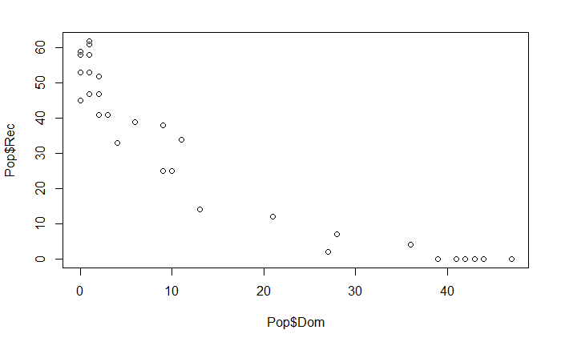

```r
plot(Pop$Dom,Pop$Rec)
```

```r
print.('We should expect that the domminant and recissive should be negativly coralated because as the number of recissive cells increases the number of domminant cells should be decreasing, and that they should have a high co-varience because they have a large spread.')
```

```
We should expect that the domminant and recissive should be negativly coralated because as the number of recissive cells increases the number of domminant cells should be decreasing, and that they should have a high co-varience because they have a large spread.
```

```r
Corr <- cor(Pop$Dom,Pop$Rec);print.('We have a correlation of ' %+% Corr %+% '. which is negative as we would expect as stated above.')
```

```
We have a correlation of -0.930223108013689. which is negative as we would expect as stated above.
```

```r
covar <- var(Pop$Dom,Pop$Rec);print.('We have a covarience of ' %+% covar %+% '. which is large and negative as we would expect as stated above.')
```

```
We have a covarience of -380.615927419355. which is large and negative as we would expect as stated above.
```

#### check if dom~rec fits to $\Gamma$ distribution

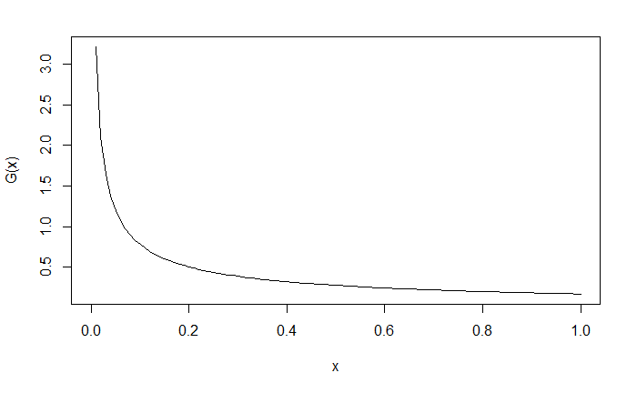

```r
X2 <- rep(Pop$Dom,Pop$Rec)

E.X <- mean(X2) #expectation
  #E.X <- sum(Pop$Dom*Pop$Rec)/sum(Pop$Rec) #this one works fine, but the above is the same format is was used for variance.

V.X <- sum((X2-E.X)^2/length(X2)) #Variance
  #V.X <- Var(Pop$Dom/Pop$Rec)


rate  <- (V.X/E.X)^(-1)
shape <- (E.X*rate)

#Γ
Γ <- function(x) {
  return(dgamma(x,shape = shape,rate = rate))
}


Γ.curve <- curve(Γ(x))
```

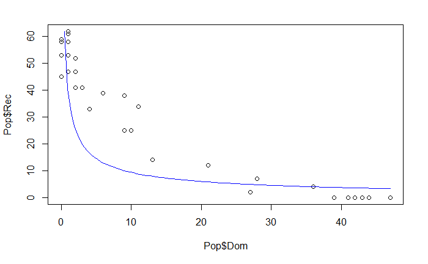

```r
#Γ.area  <-integrate(Γ,min(Pop$Dom),max(Pop$Dom))
Γ.curve.norm   <- Γ.curve
Γ.curve.norm$x <- Γ.curve$x[-1] / max(Γ.curve$x[-1]) * max(Pop$Dom)
Γ.curve.norm$y <- Γ.curve$y[-1] / max(Γ.curve$y[-1]) * max(Pop$Rec)# /Γ.area$value * sum(Pop$Dom)


plot(Pop$Dom,Pop$Rec)
points(Γ.curve.norm$x,Γ.curve.norm$y,type='l',col='blue') #pretty good expect in the second fifth
```

#### % Change with $\chi^2$ fit

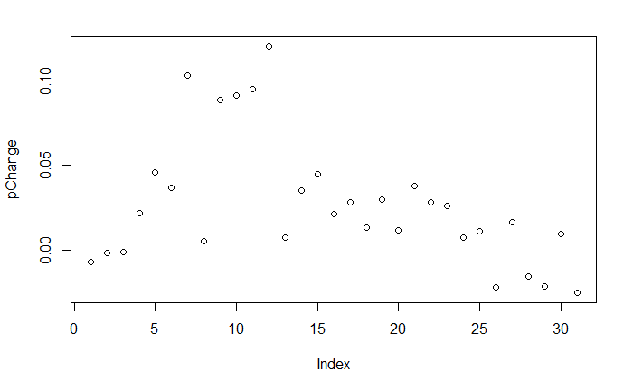

```r
pChange <- PopChange$perc.inc[-1]
len <- length(pChange)
plot(pChange)
```

```r
pChange.sum <- sum(pChange)
pChange.norm <- pChange/pChange.sum #normalized data
pChange.df <- sum(pChange.norm*1:len);print.(pChange.df) #calculates the mean, which is then used as the degrees of freedom
```

11.17577

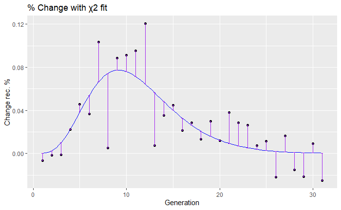

```r
scale <- integrate(dchisq,df=pChange.df,1,len)$value #area under χ2, used to scale the

x2 <- function(x) {
  ans <- dchisq(x,pChange.df) #χ2 fitted to the correct degrees of freedom
  ans %/=% scale              #divide by area under curve to normalize
  ans %*=% pChange.sum        #multiply by the area it should have
  return(ans)
}


# plot(pChange)
# curve(x2(x),add = T,col='blue') #plots the scaled and fitted χ2

Expect  <- x2(1:len)
Observe <- pChange

vals <- Expect %+% Observe
val.list <- as.list(as.data.frame(t(vals)))

data_frame <- data.frame(x=1:len,val=Observe,mins=unlist(lapply(val.list, min)),maxs=unlist(lapply(val.list, max)))

ggplot(data_frame, aes(x)) +
  stat_function(fun=x2,colour = 'blue') + #source for plotting functions: https://stackoverflow.com/questions/5177846/plot-a-function-with-ggplot-equivalent-of-curve
  geom_point( x=1:len, y=pChange)+
  geom_errorbar(aes(ymin=mins, ymax=maxs), width=.2,
                 position=position_dodge(0.05), colour = 'purple') +#source for plotting error bars: http://www.sthda.com/english/wiki/ggplot2-error-bars-quick-start-guide-r-software-and-data-visualization
  labs(x = 'Generation', y = 'Change rec. %', title = '% Change with χ2 fit')
```

```r
t.test(Observe,Expect); print.('We get a P-value of', t.test(Observe,Expect)$p.value ,'which shows that these likely come from the same distribution.')
```

```
Welch Two Sample t-test
```

data: Observe and Expect t = -0.00081078, df = 55.014, p-value = 0.9994 alternative hypothesis: true difference in means is not equal to 0 95 percent confidence interval: -0.01680231 0.01678872 sample estimates: mean of x mean of y 0.02725806 0.02726486

We get a P-value of 0.999356 which shows that these likely come from the same distribution.

```r
#Do with χ2 (this means that the data needs to be scaled)
Expect  %*=% (len / sum(pChange))
Observe  %*=% (len / sum(pChange))

X_2 <- chisq.stat(Observe,Expect); print.('$\\chi^2\\ =\\ '%+%X_2%+% '$.')
```

$\chi^2\ =\ 146.198774386747$.

```r
pchisq(X_2,29,lower.tail = FALSE); print.('<br> However, when we do a $\\chi^2$ test, we end up with a very low P-value, which would suggest that this is a bad fit.','<br><br>','It should also be noted that for both of these tests the null hypothesis is that the two data points come from the same distribution, meaning that a high P-value means that they are related. (unlike a permutation test which has independance as the null and thus the reverse meaning of P-values)')
```

[1] 1.379734e-17  
However, when we do a $\chi^2$ test, we end up with a very low P-value, which would suggest that this is a bad fit.  
It should also be noted that for both of these tests the null hypothesis is that the two data points come from the same distribution, meaning that a high P-value means that they are related. (unlike a permutation test which has independance as the null and thus the reverse meaning of P-values)